# TDevelopment_Maize

Author

Katja Holzhauser, Agronomy and Crop Science Group, Kiel University

Published

September 7, 2026

# 1 Summary

## 1.1 Descendence

The class TsubDevelopment_Maize has the following ancestor classes shown in Table 1.

Table 1: Ancestor classes of TsubDevelopment_Maize

| AncestorClass | Namespace |
| --- | --- |
| TSubmodel | UMod |
| TGraphicControl | Vcl.Controls |
| TControl | Vcl.Controls |
| TComponent | System.Classes |
| TPersistent | System.Classes |
| TObject | System |

TRUE

# 2 Scientific Background

Maize development is regulated by the effective temperature $T_{eff}$, which is calculated as the positive difference between the daily mean temperature (TMPM) and a defined base temperature of 6 °C (Tbase6), following Pages and Pellerin (1994) and Bonhomme et al. (1994) (Table 4).

The development process is divided into five stages, hereafter referred to as XStages, following the HYBRID-Maize framework and the approach of Yang et al. (2016). These XStages represent the key phenological stages of maize development: emergence, tassel initiation, silking, effective grain filling, and maturity (Fig. 1).

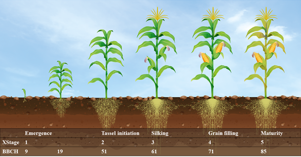

Figure 1: The XStages 1-5 represent the development stages emergence, tassel initiation, silking, effective grain filling and maturity. XStages can be converted to respected values of BBCH scale (Lancashire et al. (1991))

Development rates between the individual stages are calculated as the ratio between effective temperature ($T_{eff}$) and the corresponding temperature sums (growing degree days, GDD). Specifically, development rates are defined for the phases between sowing and emergence (Eq. 1), emergence and tassel initiation (Eq. 2), tassel initiation and silking (Eq. 3), and silking and grain filling (Eq. 4). The corresponding temperature sums are defined by the parameters $GDD_{Emergence}$, $GDD_{Tasini}$, $GDD_{Stage2}$, and $GDD_{Stage3}$ (Table 4).

$$DevRate_{S0} = \frac{T_{eff}}{{GDD}_{emergence}} \tag{1}$$

$$\mathrm{DevRateS1=}\frac{\mathrm{T}_{\mathrm{eff}}}{{\mathrm{GDD}}_{\mathrm{tasini}}} \tag{2}$$

$$\mathrm{DevRateS2=\ }\frac{\mathrm{T}_{\mathrm{eff}}}{{\mathrm{GDD}}_{\mathrm{S2}}} \tag{3}$$

$$\mathrm{DevRateS3=}\frac{\mathrm{T}_{\mathrm{eff}}}{{\mathrm{GDD}}_{\mathrm{S3}}} \tag{4}$$

Compared to the approach of Yang et al. (2016), an additional temperature sum from emergence to silking ($GDD_{Silking}$) is introduced. This parameter is used to calculate the development rate from grain filling until maturity ($Dev_{Rate,S4}$). The development rate is derived from the remaining temperature requirement between the total temperature sum to maturity ($GDD_{total}$) and the temperature sums of the preceding stages.

$$\mathrm{DevRateS4=}\frac{\mathrm{T}_{\mathrm{eff}}}{{\mathrm{GDD}}_{\mathrm{total}}\mathrm{-} {\mathrm{GDD}}_{\mathrm{emer}}\mathrm{-} {\mathrm{GDD}}_{\mathrm{silk}}\mathrm{-} {\mathrm{GDD}}_{\mathrm{S3}}} \tag{5}$$

All temperature sums are defined as cultivar-specific parameters according to the assumptions of Bignon (1990) for a mid-early maize cultivar grown on soils with medium warming dynamics. The crop is assumed to be harvested at the dough stage, corresponding to the typical harvest time of whole-crop silage maize with a dry matter content of approximately 35 %.

$$\frac{{\mathrm{dLeaf}}_{\mathrm{No}}}{\mathrm{dt}}\mathrm{\mathrm{=}}\frac{\mathrm{Teff}}{\mathrm{phy\ *\ }\mathrm{f}_{\mathrm{phy}}} \tag{6}$$

$$\mathrm{f}_{\mathrm{phy}}\mathrm{\mathrm{=}}0.66+0.068 * LeafNo \quad |\quad LeafNo < 5 \\1 \quad |\quad LeafNo ≥ 5 \tag{7}$$

During the early growth period, when the plant has fewer than five leaves (< BBCH15), leaf appearance is assumed to occur at a higher rate. To account for this effect, a reduction factor ($f_{phy}$) is applied to the phyllochron (Eq. 7).

In the field trials used for model evaluation, phenological stages were recorded according to the BBCH scale of LANCASHIRE et al. (1991). These observations were subsequently converted into the corresponding XStages for comparison with the model simulations (Fig. 1).

## 2.1 Calibration and Evaluation results

Plant development describing XStages, translated to BBCH (LANCASHIRE et al. (1991)) was simulated sufficiently with R² of 0.93 and 0.98 in calibration and evaluation (Table 2), respectively. Variations due to different sowing dates, geographical position and soil types were well estimated (Fig. 3). Inaccuracies occurred during BBCH 50 and 65, as the period of tassel initiation to silking may be difficult to quantify in the field.

Table 2: Results of model evaluation and calibration (in brackets) for development (BBCH). Performance was assessed with slope and intercept of the regression between measured and simulated data, R² and root mean square error (RMSE). n is the number of measurements.

Results of model evaluation and calibration (in brackets) for development (BBCH). Performance was assessed with slope and intercept of the regression between measured and simulated data, R² and root mean square error (RMSE). n is the number of measurements.

| Variable | Einheit | Steigung (Slope) | Achsenabschnitt (Intercept) | R² | n | RMSE |
| --- | --- | --- | --- | --- | --- | --- |
| BBCH | [d] | 0.99 (0.94) | 2.13 (7.66) | 0.98 (0.93) | 51 (183) | 4.28 (8.83) |

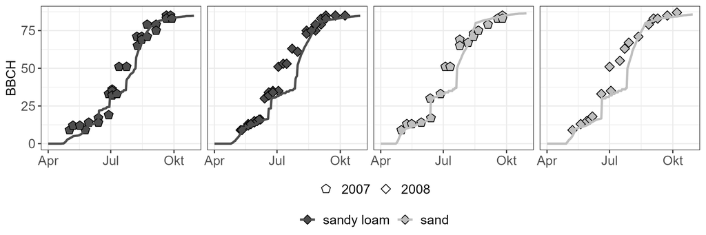

Figure 2: Model simulation of BBCH development stages (line) and measured BBCH of the calibration datasets (point) over the vegetation period of maize. Depicted are evaluation datasets of 1, 4 (site A), 3, 6 (site B) with their individual soil types starting at different sowing dates

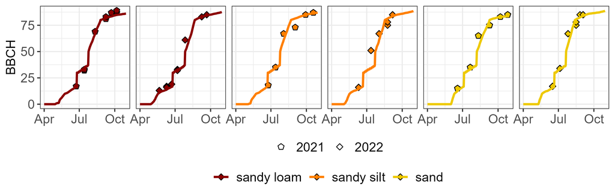

Figure 3: Model simulation of BBCH development stages (line) and measured BBCH of the evaluation datasets (point) over the vegetation period of maize. Depicted are evaluation datasets of 7, 11 (site A), 9, 13 (site C) and 10, 14 (site D) with their individual soil types starting at different sowing dates

# 3 Submodel objects

Dynamic system model consists according to the Forrester approach of state variable, parameters, variables and external driving forces. This is implemented in Hume by dynamic lists, which contents is given in the following sections.

## 3.1 State variables

The class TsubDevelopment_Maize has 10 following state variable(s).

Table 3: Initial Values of State Variables

| State variable | Units | Initial Value | Description |
| --- | --- | --- | --- |
| CumPH | [n] | 1.0000 | number of fully expanded leaves |
| CumPH_Booting | [n] | 0.0000 | number of nodes |
| DS | [-] | 0.0000 | Development stage for calculating root drymatter (See Hybrid-Maize) |
| GDD6 | [°C*d] | 0.0000 | Growing degree days from sowing |
| GDD6_from_emergence | [°C*d] | 0.0000 | growing degree days from emergence |
| GDD8 | [°C*d] | 0.0000 | Just for Information, not for calculation. |
| TLNO | [n] | 6.0000 | TLNO is the total number of leaves that will eventually appear |
| TSum_leafLagphase |  | 277.7676 |  |
| XSTAGE | [-] | 0.0000 | Phenological stage, non integer values |
| XSTAGE_till_tassel_emergence | [-] | 0.0000 |  |

TRUE

## 3.2 Parameters

The class TsubDevelopment_Maize has 17 following parameter(s).

Table 4

| Parameter | Units | Value | Description |
| --- | --- | --- | --- |
| GDD6Emergence | [°C*d] | 100.0000 | Temperature sum sowing to emergence |
| GDD6Silking | [°C*d] | 830.0000 | Temperature sum silking |
| GDD6Stage2 | [°C*d] | 510.0000 | Temperature sum tassel initiation till silking |
| GDD6Stage3 | [°C*d] | 200.0000 | Temperature sum stage 3 |
| GDD6tasini | [°C*d] | 320.0000 | Temperature sum from emergence till tassel initiation |
| GDD6total | [°C*d] | 1890.0000 | Temperature sum |
| Phyllochron | [°C*d] | 50.8000 | Phyllochron |
| Plastochron | [°C*d] | 28.1287 | Plastochron |
| sen_par | [-] | 0.0001 | en_fact wird als potenz Funktion angenommen, sen_par ist der Krümmungsfaktor dieser |
| sen_parexp | [-] | 2.0000 | en_fact wird als potenz Funktion angenommen, sen_parexp ist der Exponent dieser |
| SowingDate | [-] | 39192.0000 | Date of sowing (days from 1.1.1990) |
| Tbase6 | [°C] | 6.0000 | Base temperature |
| SowingDate | [-] | 39191.0000 | Date of sowing (days from 1.1.1990) |
| SowingDate | [-] | 39217.0000 | Date of sowing (days from 1.1.1990) |
| SowingDate | [-] | 39566.0000 | Date of sowing (days from 1.1.1990) |
| SowingDate | [-] | 39562.0000 | Date of sowing (days from 1.1.1990) |
| SowingDate | [-] | 39568.0000 | Date of sowing (days from 1.1.1990) |

TRUE

## 3.3 Variables

The class TsubDevelopment_Maize has 13 following variable(s).

Table 5: Variables, Units and Description

| Variable | Units | Description |
| --- | --- | --- |
| BBCH |  | BBCH stage |
| DevRateS0 | [1/(°Cd)] | Development rate during IStage 0 (from sowing to emergence, 0 to 1) |
| DevRateS1 | [1/(°Cd)] | development rate during IStage 1 (from emergence to tassel initiation, 1-2) |
| DevRateS2 | [1/(°Cd)] | Development rate during ISTAGE 2 (from tassel initiation to silking, 2-3) |
| DevRateS3 | [1/(°Cd)] | Development rate during ISTAGE 3 (from silking to effective grain filling, 3-4) |
| DevRateS4 | [1/(°Cd)] | Development rate during ISTAGE 4 (from effective grain filling to physiological maturity, 4-5) |
| integerXN |  | leaf nummber of the oldest expending leaf |
| ISTAGE |  | nteger growth stage indicator ranging from zero to five [0..5] |
| PC |  | Intermediate variable |
| Sen_fact |  | Seneszenzfaktor |
| Teff6 | [°C] | effective daily air temperature |
| Teff8 | [°C] | Just for Information, not for calculation. |
| TI | [°C] | Daily increase in leaf number |

TRUE

## 3.4 External variables

The class TsubDevelopment_Maize has 1 following external variable(s).

Table 6: External Variables

| External Variable | Units | Description | Source |
| --- | --- | --- | --- |
| TMPM | [Grad | Air temperature in 2 m height | Q:_TMPM_KD_06_09.txt |

TRUE

## 3.5 Options

The class TsubDevelopment_Maize has 2 following option(s).

Table 7: Options

| Option | Selection | Description |
| --- | --- | --- |
| ContOutput | true | Output every time step? |
| FinalOutput | false | Output of final values in separate file? |

TRUE

## References

Bignon, J., 1990. Agrométéorologie et physiologie du maïs grain dans la communauté européenne. CEC.

Bonhomme, R., Derieux, M., Edmeades, G.O., 1994. Flowering of diverse maize cultivars in relation to temperature and photoperiod in multilocation field trials. Crop Science 34, 156–164. https://doi.org/10.2135/cropsci1994.0011183X003400010028x

Jones, C.A., Kiniry, J.R. (Eds.), 1986. CERES-maize. A simulation model of maize growth and development. Texas A&M University Press, College Station.

LANCASHIRE, P.D., BLEIHOLDER, H., BOOM, T.V.D., LANGELÜDDEKE, P., STAUSS, R., WEBER, E., WITZENBERGER, A., 1991. A uniform decimal code for growth stages of crops and weeds. Annals of Applied Biology 119, 561–601. https://doi.org/10.1111/j.1744-7348.1991.tb04895.x

Lancashire, P.D., BLEIHOLDER, H., LANGELÜDDECKE, P., STAUSS, R., BOOM, T.V.D., Weber, E., Witzenberger, A., 1991. An uniformdecimal code for growth stages of crops and weeds. Ann. Appl. Biol. 119, 561–601.

Pages, L., Pellerin, S., 1994. Evaluation of parameters describing the root system architecture of field grown maize plants (zea mays l) . 2. Density, length, and branching of first-order lateral roots. Plant and Soil 164, 169–176.

Yang, H.S., Dobermann, A., Cassman, K.G., Walters, D.T., Grassini, P., 2016. Hybrid maize (ver. 2016): A simulation model for corn growth and yield. Nebraska Cooperative Extension, Lincoln, NE.